# Stocks_Predictive_Model

## Problem Statement

An investment company is interested in learning about the potential profit in frequent buy/sell stock transactions. You are tasked with developing a time sequence model to predict the price two days ahead based on recent prices. Choose four (or more) of the data files for training and a separate two for validation. Once the model is finalized, demonstrate how well your model makes predictions by using two other data files for testing.

```python
import numpy as np
import pandas as pd
from matplotlib import pyplot as plt
import seaborn as sb
```

```python
"""
    Function that takes a list of file names and combines them into a list then plots the data
"""
def get_data(names:list):
    dataframes = []# storing a list of dataframes as needed
    for name in names:
        temp = pd.read_csv('Stocks/'+name+'.txt')# loading data
        temp = temp[['Date', 'Close']]  # Select only the 'Date' and 'Close' columns, they are the only ones of value

        # Appending dataframes into list
        dataframes.append({'name': name, 'data': temp})
        #just plotting the closing prices for all our data to ensure some stability within the system
    for ent in dataframes:
        ent['data']['Date'] = pd.to_datetime(ent['data']['Date'])# converting object to readable date-time format
        sb.lineplot(x=ent['data']['Date'], y=ent['data']['Close'], label=ent['name'])
    plt.show()
```

## Loading our Data and Tranforming it

```python
# setting up our datafile lists to use
training_list = ['a.us', 'abus.us', 'acrs.us', 'acn.us','rmcf.us', 'eman.us', 'znga.us', 'fcx.us']
validation_list = ['gpt.us', 'cost.us', 'icpt.us', 'elp.us']
testing_list = ['aa.us', 'rmd.us', 'zx.us']
```

### Plotting our data for Insights

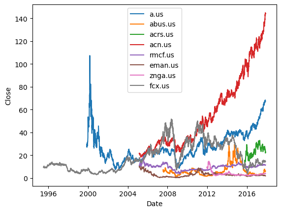

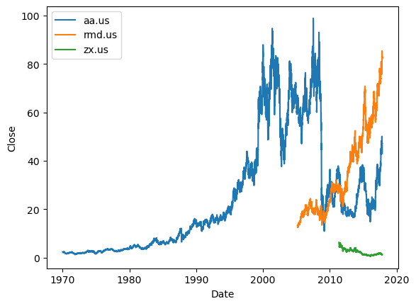

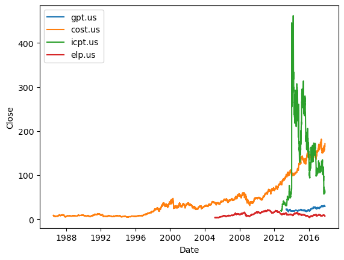

```python
train = get_data(training_list)
test = get_data(testing_list)
valid = get_data(validation_list)
```

### Converting our data into a simpler format to feed to our NN

```python
"""
A function that loads our data into dataframes, extracts needed information using only a list of file names
"""
def get_sequences(names:list, lookback:int=10):
    data_list =[]
    for name in names: # gathering our info
        temp = pd.read_csv('Stocks/'+name+'.txt')# loading data
        data_list.append(temp['Close'].values)  # Select only the'Close' column values

    data=np.concatenate(data_list, axis=0)
    inputs, labels = [], []
    for i in range(len(data) - lookback - 2):  # 2 days ahead prediction
        # Create sequences of 'lookback' length
        inputs.append(data[i:i+lookback])
        # Label is the close price two days after the end of the sequence
        labels.append(data[i+lookback+2])
    return np.array(inputs), np.array(labels)
```

```python
train_inputs, train_labels = get_sequences(training_list)
test_inputs, test_labels = get_sequences(testing_list)
valid_inputs, valid_labels = get_sequences(validation_list)
```

## Modeling

### Setting up a baseline!

```python
import tensorflow as tf
from tensorflow.keras.models import Sequential
from tensorflow.keras.layers import Conv1D, SimpleRNN, Dropout, Dense, MaxPool1D
```

```python
model = Sequential([
            Conv1D(filters=64, kernel_size=3, activation='relu', input_shape=(train_inputs.shape[1], 1)),
            SimpleRNN(units=64, activation='relu'),
            Dropout(0.1),# drops a little bit of our data to prevent overfitting
            Dense(1)  # Output layer for price prediction
                ])
```

**What is an RNN**  
An RNN (Recurrent Neural Network) is a type of neural network designed to handle sequential data, where past information is important to make predictions about the future. It processes inputs step-by-step, keeping a “memory” of past values in a hidden state that is updated as it sees each new piece of data. This memory helps the RNN learn patterns over time, making it useful for tasks like predicting trends or the next value in a sequence.

```python
model.compile(optimizer='adam', loss='mean_squared_error', metrics=['mse', 'mae'])
model.summary()
```

```
Model: "sequential"
```

```
┏━━━━━━━━━━━━━━━━━━━━━━━━━━━━━━━━━┳━━━━━━━━━━━━━━━━━━━━━━━━┳━━━━━━━━━━━━━━━┓
┃ Layer (type)                    ┃ Output Shape           ┃       Param # ┃
┡━━━━━━━━━━━━━━━━━━━━━━━━━━━━━━━━━╇━━━━━━━━━━━━━━━━━━━━━━━━╇━━━━━━━━━━━━━━━┩
│ conv1d (Conv1D)                 │ (None, 8, 64)          │           256 │
├─────────────────────────────────┼────────────────────────┼───────────────┤
│ simple_rnn (SimpleRNN)          │ (None, 64)             │         8,256 │
├─────────────────────────────────┼────────────────────────┼───────────────┤
│ dropout (Dropout)               │ (None, 64)             │             0 │
├─────────────────────────────────┼────────────────────────┼───────────────┤
│ dense (Dense)                   │ (None, 1)              │            65 │
└─────────────────────────────────┴────────────────────────┴───────────────┘
```

```
 Total params: 8,577 (33.50 KB)
```

```
 Trainable params: 8,577 (33.50 KB)
```

```
 Non-trainable params: 0 (0.00 B)
```

```python
history = model.fit(train_inputs, train_labels, epochs=20, batch_size=32)
```

```
756/756 ━━━━━━━━━━━━━━━━━━━━ 4s 2ms/step - loss: 49.5774 - mae: 3.0217 - mse: 49.5774
756/756 ━━━━━━━━━━━━━━━━━━━━ 2s 2ms/step - loss: 12.8777 - mae: 1.6234 - mse: 12.8777
756/756 ━━━━━━━━━━━━━━━━━━━━ 2s 2ms/step - loss: 10.6133 - mae: 1.5168 - mse: 10.6133
756/756 ━━━━━━━━━━━━━━━━━━━━ 2s 3ms/step - loss: 12.2333 - mae: 1.6005 - mse: 12.2333
756/756 ━━━━━━━━━━━━━━━━━━━━ 2s 3ms/step - loss: 8.9935 - mae: 1.4504 - mse: 8.9935
756/756 ━━━━━━━━━━━━━━━━━━━━ 2s 2ms/step - loss: 10.3290 - mae: 1.4908 - mse: 10.3290
756/756 ━━━━━━━━━━━━━━━━━━━━ 2s 2ms/step - loss: 8.5418 - mae: 1.4265 - mse: 8.5418
756/756 ━━━━━━━━━━━━━━━━━━━━ 2s 2ms/step - loss: 11.0216 - mae: 1.5040 - mse: 11.0216
756/756 ━━━━━━━━━━━━━━━━━━━━ 2s 2ms/step - loss: 12.9106 - mae: 1.5150 - mse: 12.9106
756/756 ━━━━━━━━━━━━━━━━━━━━ 2s 2ms/step - loss: 9.7854 - mae: 1.4376 - mse: 9.7854
756/756 ━━━━━━━━━━━━━━━━━━━━ 2s 2ms/step - loss: 11.4484 - mae: 1.4416 - mse: 11.4484
756/756 ━━━━━━━━━━━━━━━━━━━━ 2s 2ms/step - loss: 10.7195 - mae: 1.5138 - mse: 10.7195
756/756 ━━━━━━━━━━━━━━━━━━━━ 2s 3ms/step - loss: 6.7780 - mae: 1.3250 - mse: 6.7780
756/756 ━━━━━━━━━━━━━━━━━━━━ 2s 2ms/step - loss: 11.1338 - mae: 1.4772 - mse: 11.1338
756/756 ━━━━━━━━━━━━━━━━━━━━ 2s 2ms/step - loss: 10.8342 - mae: 1.4015 - mse: 10.8342
756/756 ━━━━━━━━━━━━━━━━━━━━ 2s 2ms/step - loss: 10.0747 - mae: 1.4098 - mse: 10.0747
756/756 ━━━━━━━━━━━━━━━━━━━━ 2s 2ms/step - loss: 6.7847 - mae: 1.2931 - mse: 6.7847
756/756 ━━━━━━━━━━━━━━━━━━━━ 2s 2ms/step - loss: 8.1147 - mae: 1.3066 - mse: 8.1147
756/756 ━━━━━━━━━━━━━━━━━━━━ 2s 2ms/step - loss: 7.8698 - mae: 1.3075 - mse: 7.8698
756/756 ━━━━━━━━━━━━━━━━━━━━ 2s 2ms/step - loss: 9.7181 - mae: 1.3875 - mse: 9.7181
```

```python
# Assuming validation data is prepared similarly to training data
val_preds = model.predict(valid_inputs)
model.evaluate(valid_inputs,valid_labels)
```

```
422/422 ━━━━━━━━━━━━━━━━━━━━ 1s 2ms/step
422/422 ━━━━━━━━━━━━━━━━━━━━ 1s 2ms/step - loss: 17.6035 - mae: 0.8530 - mse: 17.6035
```

```
[46.36558532714844, 46.36558532714844, 1.499799370765686]
```

#### Results

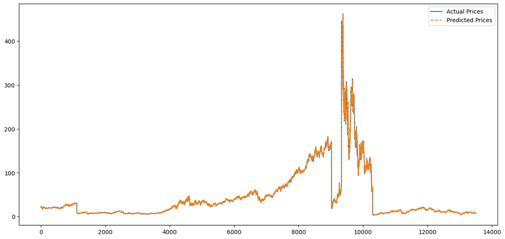

```python
plt.figure(figsize=(15, 7))
plt.plot(valid_labels, label="Actual Prices")
plt.plot(val_preds, label="Predicted Prices", linestyle="--")
plt.legend()
plt.show()
```

We see the model is very close to our original labels and though tends to predict slightly higher it is preforming well for a predictive model!

### Model 2, attempting improvement on our Baseline

```python
model2 = Sequential([
            Conv1D(filters=64, kernel_size=3, activation='relu', input_shape=(train_inputs.shape[1], 1)),
            MaxPool1D(pool_size=4),
            SimpleRNN(units=64, activation='relu',return_sequences=True),
            SimpleRNN(units=32, activation='relu'),

            Dense(10),
            Dense(1)  # Output layer for price prediction
                ])
```

```python
model2.compile(optimizer='adam', loss='mean_squared_error', metrics=['mse', 'mae'])
model2.summary()
```

```
Model: "sequential_1"
```

```
┏━━━━━━━━━━━━━━━━━━━━━━━━━━━━━━━━━┳━━━━━━━━━━━━━━━━━━━━━━━━┳━━━━━━━━━━━━━━━┓
┃ Layer (type)                    ┃ Output Shape           ┃       Param # ┃
┡━━━━━━━━━━━━━━━━━━━━━━━━━━━━━━━━━╇━━━━━━━━━━━━━━━━━━━━━━━━╇━━━━━━━━━━━━━━━┩
│ conv1d_1 (Conv1D)               │ (None, 8, 64)          │           256 │
├─────────────────────────────────┼────────────────────────┼───────────────┤
│ max_pooling1d (MaxPooling1D)    │ (None, 2, 64)          │             0 │
├─────────────────────────────────┼────────────────────────┼───────────────┤
│ simple_rnn_1 (SimpleRNN)        │ (None, 2, 64)          │         8,256 │
├─────────────────────────────────┼────────────────────────┼───────────────┤
│ simple_rnn_2 (SimpleRNN)        │ (None, 32)             │         3,104 │
├─────────────────────────────────┼────────────────────────┼───────────────┤
│ dense_1 (Dense)                 │ (None, 10)             │           330 │
├─────────────────────────────────┼────────────────────────┼───────────────┤
│ dense_2 (Dense)                 │ (None, 1)              │            11 │
└─────────────────────────────────┴────────────────────────┴───────────────┘
```

```
 Total params: 11,957 (46.71 KB)
```

```
 Trainable params: 11,957 (46.71 KB)
```

```
 Non-trainable params: 0 (0.00 B)
```

**What is MSE and MAE?**  
MSE is simply Mean Squared Error, it is a metric that gives us an idea of the average difference between our predictions and the actual labels.  
MAE is the Mean Absolute Error, it is a similar metric to MSE but instead does not look at whether a value is negative or positive and simply gives an average difference to our predictions, like a standard deviation or variance.  
With our loss being based on MSE we are getting the same values for our Loss and MSE hopefully.

```python
history2 = model2.fit(train_inputs, train_labels, epochs=20, batch_size=32)
```

```
756/756 ━━━━━━━━━━━━━━━━━━━━ 5s 2ms/step - loss: 26.8859 - mae: 1.8750 - mse: 26.8859
756/756 ━━━━━━━━━━━━━━━━━━━━ 2s 2ms/step - loss: 7.5028 - mae: 1.0300 - mse: 7.5028
756/756 ━━━━━━━━━━━━━━━━━━━━ 2s 2ms/step - loss: 5.1518 - mae: 0.8974 - mse: 5.1518
756/756 ━━━━━━━━━━━━━━━━━━━━ 2s 2ms/step - loss: 4.6534 - mae: 0.8858 - mse: 4.6534
756/756 ━━━━━━━━━━━━━━━━━━━━ 2s 2ms/step - loss: 6.2428 - mae: 0.9977 - mse: 6.2428
756/756 ━━━━━━━━━━━━━━━━━━━━ 2s 3ms/step - loss: 5.5005 - mae: 0.8843 - mse: 5.5005
756/756 ━━━━━━━━━━━━━━━━━━━━ 2s 2ms/step - loss: 4.7819 - mae: 0.8294 - mse: 4.7819
756/756 ━━━━━━━━━━━━━━━━━━━━ 2s 2ms/step - loss: 3.5583 - mae: 0.7834 - mse: 3.5583
756/756 ━━━━━━━━━━━━━━━━━━━━ 2s 2ms/step - loss: 7.5844 - mae: 0.9653 - mse: 7.5844
756/756 ━━━━━━━━━━━━━━━━━━━━ 2s 2ms/step - loss: 10.7110 - mae: 1.1688 - mse: 10.7110
756/756 ━━━━━━━━━━━━━━━━━━━━ 2s 2ms/step - loss: 4.0890 - mae: 0.7914 - mse: 4.0890
756/756 ━━━━━━━━━━━━━━━━━━━━ 2s 3ms/step - loss: 8.8674 - mae: 1.2185 - mse: 8.8674
756/756 ━━━━━━━━━━━━━━━━━━━━ 2s 2ms/step - loss: 4.6008 - mae: 0.8392 - mse: 4.6008
756/756 ━━━━━━━━━━━━━━━━━━━━ 2s 2ms/step - loss: 7.8473 - mae: 0.9424 - mse: 7.8473
756/756 ━━━━━━━━━━━━━━━━━━━━ 2s 2ms/step - loss: 6.2692 - mae: 0.8842 - mse: 6.2692
756/756 ━━━━━━━━━━━━━━━━━━━━ 2s 3ms/step - loss: 4.5685 - mae: 0.8079 - mse: 4.5685
756/756 ━━━━━━━━━━━━━━━━━━━━ 2s 3ms/step - loss: 7.3655 - mae: 0.9324 - mse: 7.3655
756/756 ━━━━━━━━━━━━━━━━━━━━ 2s 2ms/step - loss: 5.2727 - mae: 0.8459 - mse: 5.2727
756/756 ━━━━━━━━━━━━━━━━━━━━ 2s 2ms/step - loss: 5.8125 - mae: 0.9074 - mse: 5.8125
756/756 ━━━━━━━━━━━━━━━━━━━━ 2s 2ms/step - loss: 4.3598 - mae: 0.7898 - mse: 4.3598
```

```python
val_preds = model2.predict(valid_inputs)
model2.evaluate(valid_inputs,valid_labels)
```

```
422/422 ━━━━━━━━━━━━━━━━━━━━ 1s 2ms/step
422/422 ━━━━━━━━━━━━━━━━━━━━ 1s 1ms/step - loss: 20.0921 - mae: 0.9408 - mse: 20.0921
```

```
[53.406517028808594, 53.406517028808594, 1.6864348649978638]
```

#### Results

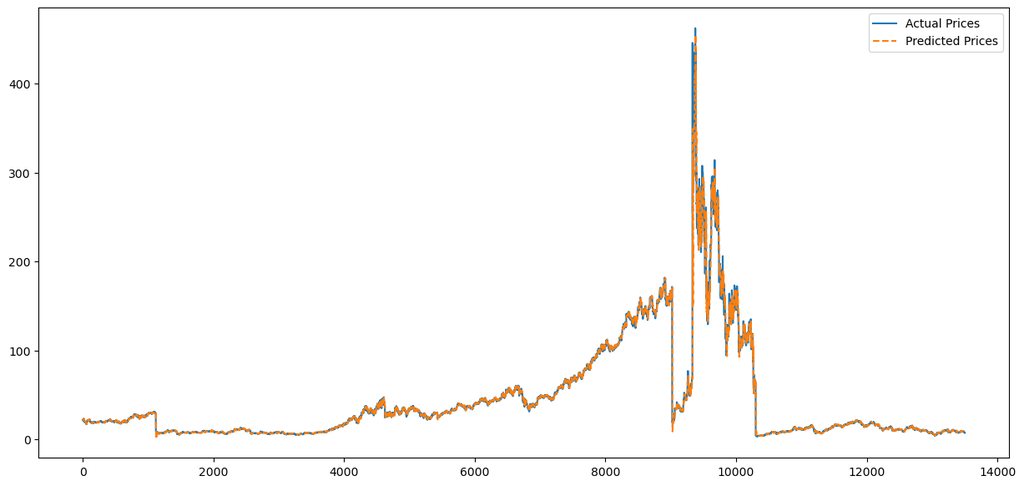

```python
plt.figure(figsize=(15, 7))
plt.plot(valid_labels, label="Actual Prices")
plt.plot(val_preds, label="Predicted Prices", linestyle="--")
plt.legend()
plt.show()
```

This model predicted our large increase early, not the best result as early selling loses profit!

### Model 3, attempting to unify our two models into a single powerful model

```python
model3 = Sequential([
            Conv1D(filters=64, kernel_size=3, activation='relu', input_shape=(train_inputs.shape[1], 1)),
            MaxPool1D(pool_size=4),
            SimpleRNN(units=128, activation='relu',return_sequences=True),
            SimpleRNN(units=64, activation='relu'), # I like the dual RNN

            Dropout(0.1),# seemed to help our baseline deal with our outliers
            Dense(1)  # Output layer for price prediction
                ])
```

```python
model3.compile(optimizer='adam', loss='mean_squared_error', metrics=['mse', 'mae'])
model3.summary()
```

```
Model: "sequential_2"
```

```
┏━━━━━━━━━━━━━━━━━━━━━━━━━━━━━━━━━┳━━━━━━━━━━━━━━━━━━━━━━━━┳━━━━━━━━━━━━━━━┓
┃ Layer (type)                    ┃ Output Shape           ┃       Param # ┃
┡━━━━━━━━━━━━━━━━━━━━━━━━━━━━━━━━━╇━━━━━━━━━━━━━━━━━━━━━━━━╇━━━━━━━━━━━━━━━┩
│ conv1d_2 (Conv1D)               │ (None, 8, 64)          │           256 │
├─────────────────────────────────┼────────────────────────┼───────────────┤
│ max_pooling1d_1 (MaxPooling1D)  │ (None, 2, 64)          │             0 │
├─────────────────────────────────┼────────────────────────┼───────────────┤
│ simple_rnn_3 (SimpleRNN)        │ (None, 2, 128)         │        24,704 │
├─────────────────────────────────┼────────────────────────┼───────────────┤
│ simple_rnn_4 (SimpleRNN)        │ (None, 64)             │        12,352 │
├─────────────────────────────────┼────────────────────────┼───────────────┤
│ dropout_1 (Dropout)             │ (None, 64)             │             0 │
├─────────────────────────────────┼────────────────────────┼───────────────┤
│ dense_3 (Dense)                 │ (None, 1)              │            65 │
└─────────────────────────────────┴────────────────────────┴───────────────┘
```

```
 Total params: 37,377 (146.00 KB)
```

```
 Trainable params: 37,377 (146.00 KB)
```

```
 Non-trainable params: 0 (0.00 B)
```

```python
history3 = model3.fit(train_inputs, train_labels, epochs=20, batch_size=32)
```

```
756/756 ━━━━━━━━━━━━━━━━━━━━ 5s 3ms/step - loss: 69.5613 - mae: 3.6873 - mse: 69.5613
756/756 ━━━━━━━━━━━━━━━━━━━━ 2s 3ms/step - loss: 14.5738 - mae: 1.9067 - mse: 14.5738
756/756 ━━━━━━━━━━━━━━━━━━━━ 2s 3ms/step - loss: 12.1631 - mae: 1.8157 - mse: 12.1631
756/756 ━━━━━━━━━━━━━━━━━━━━ 2s 3ms/step - loss: 14.9234 - mae: 1.8725 - mse: 14.9234
756/756 ━━━━━━━━━━━━━━━━━━━━ 2s 2ms/step - loss: 13.5999 - mae: 1.8338 - mse: 13.5999
756/756 ━━━━━━━━━━━━━━━━━━━━ 2s 2ms/step - loss: 11.4631 - mae: 1.7356 - mse: 11.4631
756/756 ━━━━━━━━━━━━━━━━━━━━ 2s 2ms/step - loss: 13.9846 - mae: 1.7406 - mse: 13.9846
756/756 ━━━━━━━━━━━━━━━━━━━━ 2s 3ms/step - loss: 10.3968 - mae: 1.6822 - mse: 10.3968
756/756 ━━━━━━━━━━━━━━━━━━━━ 2s 3ms/step - loss: 10.2361 - mae: 1.6627 - mse: 10.2361
756/756 ━━━━━━━━━━━━━━━━━━━━ 2s 3ms/step - loss: 12.8242 - mae: 1.7483 - mse: 12.8242
756/756 ━━━━━━━━━━━━━━━━━━━━ 2s 3ms/step - loss: 10.8127 - mae: 1.6440 - mse: 10.8127
756/756 ━━━━━━━━━━━━━━━━━━━━ 2s 3ms/step - loss: 10.7543 - mae: 1.6529 - mse: 10.7543
756/756 ━━━━━━━━━━━━━━━━━━━━ 2s 2ms/step - loss: 12.0091 - mae: 1.6843 - mse: 12.0091
756/756 ━━━━━━━━━━━━━━━━━━━━ 2s 3ms/step - loss: 14.4295 - mae: 1.7245 - mse: 14.4295
756/756 ━━━━━━━━━━━━━━━━━━━━ 2s 3ms/step - loss: 9.7063 - mae: 1.5510 - mse: 9.7063
756/756 ━━━━━━━━━━━━━━━━━━━━ 2s 2ms/step - loss: 11.9739 - mae: 1.6298 - mse: 11.9739
756/756 ━━━━━━━━━━━━━━━━━━━━ 2s 3ms/step - loss: 9.4212 - mae: 1.5259 - mse: 9.4212
756/756 ━━━━━━━━━━━━━━━━━━━━ 2s 3ms/step - loss: 11.3648 - mae: 1.6193 - mse: 11.3648
756/756 ━━━━━━━━━━━━━━━━━━━━ 2s 3ms/step - loss: 8.3522 - mae: 1.5046 - mse: 8.3522
756/756 ━━━━━━━━━━━━━━━━━━━━ 2s 2ms/step - loss: 14.2027 - mae: 1.6703 - mse: 14.2027
```

```python
val_preds = model3.predict(valid_inputs)
model3.evaluate(valid_inputs,valid_labels)
```

```
422/422 ━━━━━━━━━━━━━━━━━━━━ 1s 2ms/step
422/422 ━━━━━━━━━━━━━━━━━━━━ 1s 1ms/step - loss: 23.8796 - mae: 1.0269 - mse: 23.8796
```

```
[61.67457580566406, 61.67457580566406, 1.818865180015564]
```

#### Results

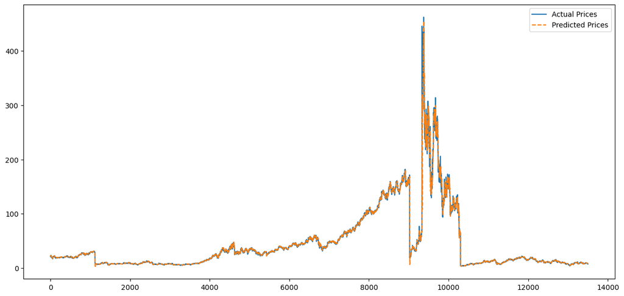

```python
plt.figure(figsize=(15, 7))
plt.plot(valid_labels, label="Actual Prices")
plt.plot(val_preds, label="Predicted Prices", linestyle="--")
plt.legend()
plt.show()
```

### Model 4, Attempting something new and crazy!

```python
model4 = Sequential([
            Conv1D(filters=64, kernel_size=3, activation='relu', input_shape=(train_inputs.shape[1], 1)),
            Conv1D(filters=32, kernel_size=2, activation='relu'),
            SimpleRNN(units=64, activation='relu',return_sequences=True),
            SimpleRNN(units=32, activation='relu', return_sequences=True),
            SimpleRNN(units=16, activation='relu'),

            Dropout(0.1),
            Dense(1)  # Output layer for price prediction
                ])
```

```python
model4.compile(optimizer='adam', loss='mean_squared_error', metrics=['mse', 'mae'])
model4.summary()
```

```
Model: "sequential_3"
```

```
┏━━━━━━━━━━━━━━━━━━━━━━━━━━━━━━━━━┳━━━━━━━━━━━━━━━━━━━━━━━━┳━━━━━━━━━━━━━━━┓
┃ Layer (type)                    ┃ Output Shape           ┃       Param # ┃
┡━━━━━━━━━━━━━━━━━━━━━━━━━━━━━━━━━╇━━━━━━━━━━━━━━━━━━━━━━━━╇━━━━━━━━━━━━━━━┩
│ conv1d_3 (Conv1D)               │ (None, 8, 64)          │           256 │
├─────────────────────────────────┼────────────────────────┼───────────────┤
│ conv1d_4 (Conv1D)               │ (None, 7, 32)          │         4,128 │
├─────────────────────────────────┼────────────────────────┼───────────────┤
│ simple_rnn_5 (SimpleRNN)        │ (None, 7, 64)          │         6,208 │
├─────────────────────────────────┼────────────────────────┼───────────────┤
│ simple_rnn_6 (SimpleRNN)        │ (None, 7, 32)          │         3,104 │
├─────────────────────────────────┼────────────────────────┼───────────────┤
│ simple_rnn_7 (SimpleRNN)        │ (None, 16)             │           784 │
├─────────────────────────────────┼────────────────────────┼───────────────┤
│ dropout_2 (Dropout)             │ (None, 16)             │             0 │
├─────────────────────────────────┼────────────────────────┼───────────────┤
│ dense_4 (Dense)                 │ (None, 1)              │            17 │
└─────────────────────────────────┴────────────────────────┴───────────────┘
```

```
 Total params: 14,497 (56.63 KB)
```

```
 Trainable params: 14,497 (56.63 KB)
```

```
 Non-trainable params: 0 (0.00 B)
```

```python
history4 = model4.fit(train_inputs, train_labels, epochs=20, batch_size=16)
```

```
1512/1512 ━━━━━━━━━━━━━━━━━━━━ 11s 5ms/step - loss: 47.1946 - mae: 3.2827 - mse: 47.1946
1512/1512 ━━━━━━━━━━━━━━━━━━━━ 7s 4ms/step - loss: 30.3732 - mae: 2.7777 - mse: 30.3732
1512/1512 ━━━━━━━━━━━━━━━━━━━━ 6s 4ms/step - loss: 28.0745 - mae: 2.6336 - mse: 28.0745
1512/1512 ━━━━━━━━━━━━━━━━━━━━ 7s 4ms/step - loss: 36.3773 - mae: 2.7640 - mse: 36.3773
1512/1512 ━━━━━━━━━━━━━━━━━━━━ 6s 4ms/step - loss: 24.9705 - mae: 2.4830 - mse: 24.9705
1512/1512 ━━━━━━━━━━━━━━━━━━━━ 7s 4ms/step - loss: 28.4203 - mae: 2.5149 - mse: 28.4203
1512/1512 ━━━━━━━━━━━━━━━━━━━━ 6s 4ms/step - loss: 25.7178 - mae: 2.4899 - mse: 25.7178
1512/1512 ━━━━━━━━━━━━━━━━━━━━ 7s 5ms/step - loss: 20.0549 - mae: 2.2423 - mse: 20.0549
1512/1512 ━━━━━━━━━━━━━━━━━━━━ 6s 4ms/step - loss: 22.2965 - mae: 2.2895 - mse: 22.2965
1512/1512 ━━━━━━━━━━━━━━━━━━━━ 6s 4ms/step - loss: 19.6814 - mae: 2.2058 - mse: 19.6814
1512/1512 ━━━━━━━━━━━━━━━━━━━━ 7s 4ms/step - loss: 20.8869 - mae: 2.2339 - mse: 20.8869
1512/1512 ━━━━━━━━━━━━━━━━━━━━ 6s 4ms/step - loss: 17.8089 - mae: 2.1215 - mse: 17.8089
1512/1512 ━━━━━━━━━━━━━━━━━━━━ 6s 4ms/step - loss: 19.3721 - mae: 2.1310 - mse: 19.3721
1512/1512 ━━━━━━━━━━━━━━━━━━━━ 7s 4ms/step - loss: 22.5079 - mae: 2.2253 - mse: 22.5079
1512/1512 ━━━━━━━━━━━━━━━━━━━━ 7s 4ms/step - loss: 19.0287 - mae: 2.1088 - mse: 19.0287
1512/1512 ━━━━━━━━━━━━━━━━━━━━ 7s 4ms/step - loss: 18.9618 - mae: 2.0819 - mse: 18.9618
1512/1512 ━━━━━━━━━━━━━━━━━━━━ 6s 4ms/step - loss: 16.4704 - mae: 2.0417 - mse: 16.4704
1512/1512 ━━━━━━━━━━━━━━━━━━━━ 7s 4ms/step - loss: 18.1649 - mae: 2.0604 - mse: 18.1649
1512/1512 ━━━━━━━━━━━━━━━━━━━━ 7s 4ms/step - loss: 17.8678 - mae: 2.0559 - mse: 17.8678
1512/1512 ━━━━━━━━━━━━━━━━━━━━ 7s 4ms/step - loss: 16.2019 - mae: 1.9842 - mse: 16.2019
```

```python
val_preds = model4.predict(valid_inputs)
model4.evaluate(valid_inputs,valid_labels)
```

```
422/422 ━━━━━━━━━━━━━━━━━━━━ 1s 2ms/step
422/422 ━━━━━━━━━━━━━━━━━━━━ 1s 2ms/step - loss: 19.9594 - mae: 1.2178 - mse: 19.9594
```

```
[51.949161529541016, 51.949161529541016, 2.1216931343078613]
```

#### Results

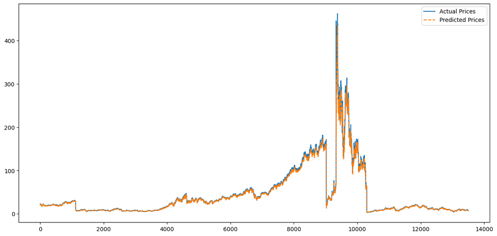

```python
plt.figure(figsize=(15, 7))
plt.plot(valid_labels, label="Actual Prices")
plt.plot(val_preds, label="Predicted Prices", linestyle="--")
plt.legend()
plt.show()
```

## Choosing our Best and Brightest

```python
test_preds = model.predict(test_inputs)
```

```
528/528 ━━━━━━━━━━━━━━━━━━━━ 1s 1ms/step
```

```python
model.evaluate(test_inputs,test_labels)
```

```
528/528 ━━━━━━━━━━━━━━━━━━━━ 1s 1ms/step - loss: 1.1300 - mae: 0.4257 - mse: 1.1300
```

```
[2.845486879348755, 2.845486879348755, 0.69704669713974]
```

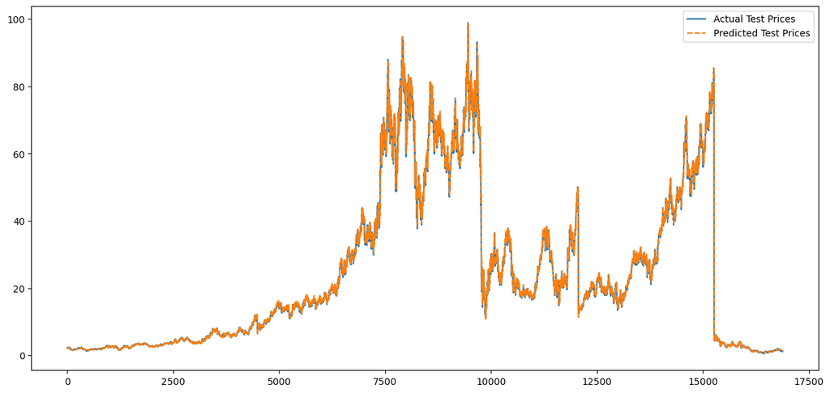

```python
plt.figure(figsize=(15, 7))
plt.plot(test_labels, label="Actual Test Prices")
plt.plot(test_preds, label="Predicted Test Prices", linestyle="--")
plt.legend()
plt.show()
```

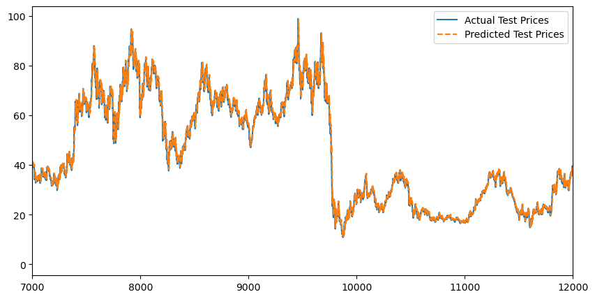

```python
plt.figure(figsize=(10, 5))
plt.plot(test_labels, label="Actual Test Prices")
plt.plot(test_preds, label="Predicted Test Prices", linestyle="--")
plt.legend()
plt.xlim(7000, 12000)
plt.show()
```

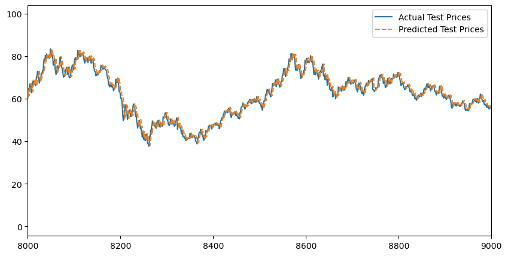

```python
plt.figure(figsize=(10, 5))
plt.plot(test_labels, label="Actual Test Prices")
plt.plot(test_preds, label="Predicted Test Prices", linestyle="--")
plt.legend()
plt.xlim(8000, 9000)
plt.show()
```

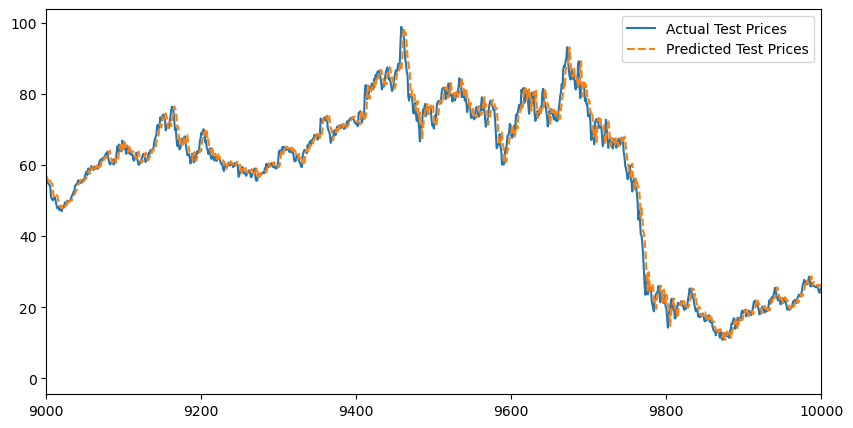

```python
plt.figure(figsize=(10, 5))
plt.plot(test_labels, label="Actual Test Prices")
plt.plot(test_preds, label="Predicted Test Prices", linestyle="--")
plt.legend()
plt.xlim(9000, 10000)
plt.show()
```